# Risk Factor Analysis

## Outcome Variable

**Outcome Variable:** sstunted

## Predictor Variables

**Intervention Variable:** single

**Adjustment Set:**

- arm
- W_mage
- meducyrs
- feducyrs
- W_mhtcm
- W_mwtkg
- W_mbmi
- delta_W_mage
- delta_meducyrs
- delta_feducyrs
- delta_W_mhtcm
- delta_W_mwtkg
- delta_W_mbmi

## Stratifying Variables

The analysis was stratified on these variable(s):

- agecat
- studyid
- country

## Data Summary

| agecat | studyid | country | single | sstunted | n_cell | n |
| --- | --- | --- | --- | --- | --- | --- |
| Birth | ki0047075b-MAL-ED | BANGLADESH | 0 | 0 | 222 | 231 |
| Birth | ki0047075b-MAL-ED | BANGLADESH | 0 | 1 | 9 | 231 |
| Birth | ki0047075b-MAL-ED | BANGLADESH | 1 | 0 | 0 | 231 |
| Birth | ki0047075b-MAL-ED | BANGLADESH | 1 | 1 | 0 | 231 |
| Birth | ki0047075b-MAL-ED | BRAZIL | 0 | 0 | 55 | 65 |
| Birth | ki0047075b-MAL-ED | BRAZIL | 0 | 1 | 2 | 65 |
| Birth | ki0047075b-MAL-ED | BRAZIL | 1 | 0 | 7 | 65 |
| Birth | ki0047075b-MAL-ED | BRAZIL | 1 | 1 | 1 | 65 |
| Birth | ki0047075b-MAL-ED | INDIA | 0 | 0 | 45 | 47 |
| Birth | ki0047075b-MAL-ED | INDIA | 0 | 1 | 2 | 47 |
| Birth | ki0047075b-MAL-ED | INDIA | 1 | 0 | 0 | 47 |
| Birth | ki0047075b-MAL-ED | INDIA | 1 | 1 | 0 | 47 |
| Birth | ki0047075b-MAL-ED | NEPAL | 0 | 0 | 26 | 27 |
| Birth | ki0047075b-MAL-ED | NEPAL | 0 | 1 | 1 | 27 |
| Birth | ki0047075b-MAL-ED | NEPAL | 1 | 0 | 0 | 27 |
| Birth | ki0047075b-MAL-ED | NEPAL | 1 | 1 | 0 | 27 |
| Birth | ki0047075b-MAL-ED | PERU | 0 | 0 | 206 | 233 |
| Birth | ki0047075b-MAL-ED | PERU | 0 | 1 | 3 | 233 |
| Birth | ki0047075b-MAL-ED | PERU | 1 | 0 | 23 | 233 |
| Birth | ki0047075b-MAL-ED | PERU | 1 | 1 | 1 | 233 |
| Birth | ki0047075b-MAL-ED | SOUTH AFRICA | 0 | 0 | 63 | 123 |
| Birth | ki0047075b-MAL-ED | SOUTH AFRICA | 0 | 1 | 0 | 123 |
| Birth | ki0047075b-MAL-ED | SOUTH AFRICA | 1 | 0 | 58 | 123 |
| Birth | ki0047075b-MAL-ED | SOUTH AFRICA | 1 | 1 | 2 | 123 |
| Birth | ki0047075b-MAL-ED | TANZANIA, UNITED REPUBLIC OF | 0 | 0 | 112 | 125 |
| Birth | ki0047075b-MAL-ED | TANZANIA, UNITED REPUBLIC OF | 0 | 1 | 10 | 125 |
| Birth | ki0047075b-MAL-ED | TANZANIA, UNITED REPUBLIC OF | 1 | 0 | 3 | 125 |
| Birth | ki0047075b-MAL-ED | TANZANIA, UNITED REPUBLIC OF | 1 | 1 | 0 | 125 |
| Birth | ki1119695-PROBIT | BELARUS | 0 | 0 | 13343 | 13890 |
| Birth | ki1119695-PROBIT | BELARUS | 0 | 1 | 5 | 13890 |

[output cut: 138 more lines]

The following strata were considered:

- agecat: 24 months, studyid: ki0047075b-MAL-ED, country: BANGLADESH
- agecat: 24 months, studyid: ki0047075b-MAL-ED, country: BRAZIL
- agecat: 24 months, studyid: ki0047075b-MAL-ED, country: INDIA
- agecat: 24 months, studyid: ki0047075b-MAL-ED, country: NEPAL
- agecat: 24 months, studyid: ki0047075b-MAL-ED, country: PERU
- agecat: 24 months, studyid: ki0047075b-MAL-ED, country: SOUTH AFRICA
- agecat: 24 months, studyid: ki0047075b-MAL-ED, country: TANZANIA, UNITED REPUBLIC OF
- agecat: 24 months, studyid: ki1066203-TanzaniaChild2, country: TANZANIA, UNITED REPUBLIC OF
- agecat: 24 months, studyid: ki1119695-PROBIT, country: BELARUS
- agecat: 24 months, studyid: ki1126311-ZVITAMBO, country: ZIMBABWE
- agecat: 24 months, studyid: ki1135781-COHORTS, country: GUATEMALA
- agecat: 24 months, studyid: ki1135781-COHORTS, country: INDIA
- agecat: 24 months, studyid: ki1135781-COHORTS, country: PHILIPPINES
- agecat: 24 months, studyid: kiGH5241-JiVitA-4, country: BANGLADESH
- agecat: 6 months, studyid: ki0047075b-MAL-ED, country: BANGLADESH
- agecat: 6 months, studyid: ki0047075b-MAL-ED, country: BRAZIL
- agecat: 6 months, studyid: ki0047075b-MAL-ED, country: INDIA
- agecat: 6 months, studyid: ki0047075b-MAL-ED, country: NEPAL
- agecat: 6 months, studyid: ki0047075b-MAL-ED, country: PERU
- agecat: 6 months, studyid: ki0047075b-MAL-ED, country: SOUTH AFRICA
- agecat: 6 months, studyid: ki0047075b-MAL-ED, country: TANZANIA, UNITED REPUBLIC OF
- agecat: 6 months, studyid: ki1066203-TanzaniaChild2, country: TANZANIA, UNITED REPUBLIC OF
- agecat: 6 months, studyid: ki1112895-Guatemala BSC, country: GUATEMALA
- agecat: 6 months, studyid: ki1119695-PROBIT, country: BELARUS
- agecat: 6 months, studyid: ki1126311-ZVITAMBO, country: ZIMBABWE
- agecat: 6 months, studyid: ki1135781-COHORTS, country: GUATEMALA
- agecat: 6 months, studyid: ki1135781-COHORTS, country: INDIA
- agecat: 6 months, studyid: ki1135781-COHORTS, country: PHILIPPINES
- agecat: 6 months, studyid: kiGH5241-JiVitA-4, country: BANGLADESH
- agecat: Birth, studyid: ki0047075b-MAL-ED, country: BANGLADESH
- agecat: Birth, studyid: ki0047075b-MAL-ED, country: BRAZIL
- agecat: Birth, studyid: ki0047075b-MAL-ED, country: INDIA
- agecat: Birth, studyid: ki0047075b-MAL-ED, country: NEPAL
- agecat: Birth, studyid: ki0047075b-MAL-ED, country: PERU
- agecat: Birth, studyid: ki0047075b-MAL-ED, country: SOUTH AFRICA
- agecat: Birth, studyid: ki0047075b-MAL-ED, country: TANZANIA, UNITED REPUBLIC OF
- agecat: Birth, studyid: ki1119695-PROBIT, country: BELARUS
- agecat: Birth, studyid: ki1126311-ZVITAMBO, country: ZIMBABWE
- agecat: Birth, studyid: ki1135781-COHORTS, country: GUATEMALA
- agecat: Birth, studyid: ki1135781-COHORTS, country: INDIA
- agecat: Birth, studyid: ki1135781-COHORTS, country: PHILIPPINES
- agecat: Birth, studyid: kiGH5241-JiVitA-4, country: BANGLADESH

### Dropped Strata

Some strata were dropped due to rare outcomes:

- agecat: Birth, studyid: ki0047075b-MAL-ED, country: BANGLADESH
- agecat: Birth, studyid: ki0047075b-MAL-ED, country: BRAZIL
- agecat: Birth, studyid: ki0047075b-MAL-ED, country: INDIA
- agecat: Birth, studyid: ki0047075b-MAL-ED, country: NEPAL
- agecat: Birth, studyid: ki0047075b-MAL-ED, country: PERU
- agecat: Birth, studyid: ki0047075b-MAL-ED, country: SOUTH AFRICA
- agecat: Birth, studyid: ki0047075b-MAL-ED, country: TANZANIA, UNITED REPUBLIC OF
- agecat: Birth, studyid: ki1119695-PROBIT, country: BELARUS
- agecat: Birth, studyid: ki1135781-COHORTS, country: GUATEMALA
- agecat: Birth, studyid: ki1135781-COHORTS, country: INDIA
- agecat: Birth, studyid: ki1135781-COHORTS, country: PHILIPPINES
- agecat: Birth, studyid: kiGH5241-JiVitA-4, country: BANGLADESH
- agecat: 6 months, studyid: ki0047075b-MAL-ED, country: BANGLADESH
- agecat: 6 months, studyid: ki0047075b-MAL-ED, country: BRAZIL
- agecat: 6 months, studyid: ki0047075b-MAL-ED, country: INDIA
- agecat: 6 months, studyid: ki0047075b-MAL-ED, country: NEPAL
- agecat: 6 months, studyid: ki0047075b-MAL-ED, country: PERU
- agecat: 6 months, studyid: ki0047075b-MAL-ED, country: SOUTH AFRICA
- agecat: 6 months, studyid: ki0047075b-MAL-ED, country: TANZANIA, UNITED REPUBLIC OF
- agecat: 6 months, studyid: ki1066203-TanzaniaChild2, country: TANZANIA, UNITED REPUBLIC OF
- agecat: 6 months, studyid: ki1135781-COHORTS, country: INDIA
- agecat: 6 months, studyid: ki1135781-COHORTS, country: PHILIPPINES
- agecat: 6 months, studyid: kiGH5241-JiVitA-4, country: BANGLADESH
- agecat: 24 months, studyid: ki0047075b-MAL-ED, country: BANGLADESH
- agecat: 24 months, studyid: ki0047075b-MAL-ED, country: BRAZIL
- agecat: 24 months, studyid: ki0047075b-MAL-ED, country: INDIA
- agecat: 24 months, studyid: ki0047075b-MAL-ED, country: NEPAL
- agecat: 24 months, studyid: ki0047075b-MAL-ED, country: PERU
- agecat: 24 months, studyid: ki0047075b-MAL-ED, country: TANZANIA, UNITED REPUBLIC OF
- agecat: 24 months, studyid: ki1066203-TanzaniaChild2, country: TANZANIA, UNITED REPUBLIC OF
- agecat: 24 months, studyid: ki1119695-PROBIT, country: BELARUS
- agecat: 24 months, studyid: ki1135781-COHORTS, country: INDIA
- agecat: 24 months, studyid: kiGH5241-JiVitA-4, country: BANGLADESH

## Methods Detail

We’re interested in the causal parameters $E[Y_a]$ for all values of $a \in \mathcal{A}$. These parameters represent the mean outcome if, possibly contrary to fact, we intervened to set all units to have $A=a$. Under the randomization and positivity assumptions, these are identified by the statistical parameters $\psi_a=E_W[E_{Y|A,W}(Y|A=a,W)]$. In addition, we’re interested in the mean of $Y$, $E[Y]$ under no intervention (the observed mean). We will estimate these parameters by using SuperLearner to fit the relevant likelihood factors – $E_{Y|A,W}(Y|A=a,W)$ and $p(A=a|W)$, and then updating our likelihood fit using a joint TMLE.

For unadjusted analyses ($W=\{\}$), initial likelihoods were estimated using Lrnr_glm to estimate the simple $E(Y|A)$ and Lrnr_mean to estimate $p(A)$. For adjusted analyses, a small library containing Lrnr_glmnet, Lrnr_xgboost, and Lrnr_mean was used.

Having estimated these parameters, we will then use the delta method to estimate relative risks and attributable risks relative to a prespecified baseline level of $A$.

# Results Detail

## Results Plots

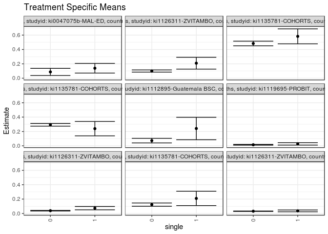

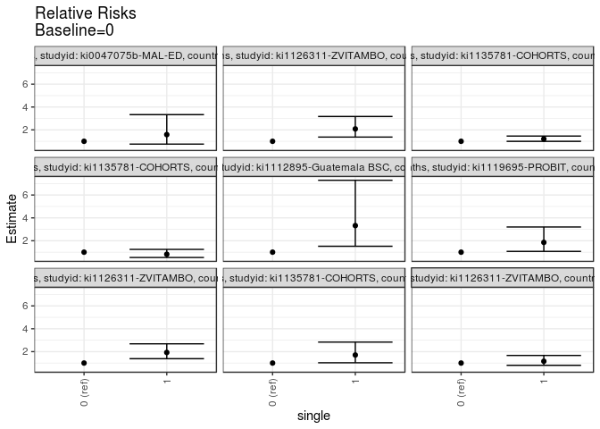

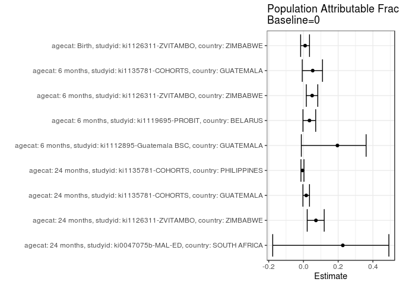

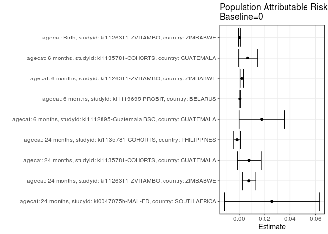

## Results Table

### Parameter: TSM

| agecat | studyid | country | intervention_level | baseline_level | estimate | ci_lower | ci_upper |
| --- | --- | --- | --- | --- | --- | --- | --- |
| Birth | ki1126311-ZVITAMBO | ZIMBABWE | 0 | NA | 0.0314615 | 0.0284535 | 0.0344695 |
| Birth | ki1126311-ZVITAMBO | ZIMBABWE | 1 | NA | 0.0363682 | 0.0235534 | 0.0491830 |
| 6 months | ki1112895-Guatemala BSC | GUATEMALA | 0 | NA | 0.0725806 | 0.0402320 | 0.1049293 |
| 6 months | ki1112895-Guatemala BSC | GUATEMALA | 1 | NA | 0.2413793 | 0.0853534 | 0.3974052 |
| 6 months | ki1119695-PROBIT | BELARUS | 0 | NA | 0.0148838 | 0.0095889 | 0.0201787 |
| 6 months | ki1119695-PROBIT | BELARUS | 1 | NA | 0.0275942 | 0.0108230 | 0.0443653 |
| 6 months | ki1126311-ZVITAMBO | ZIMBABWE | 0 | NA | 0.0384916 | 0.0343095 | 0.0426737 |
| 6 months | ki1126311-ZVITAMBO | ZIMBABWE | 1 | NA | 0.0740736 | 0.0508143 | 0.0973329 |
| 6 months | ki1135781-COHORTS | GUATEMALA | 0 | NA | 0.1229789 | 0.1005328 | 0.1454249 |
| 6 months | ki1135781-COHORTS | GUATEMALA | 1 | NA | 0.2094615 | 0.1097757 | 0.3091472 |
| 24 months | ki0047075b-MAL-ED | SOUTH AFRICA | 0 | NA | 0.0877205 | 0.0380110 | 0.1374299 |
| 24 months | ki0047075b-MAL-ED | SOUTH AFRICA | 1 | NA | 0.1390393 | 0.0721367 | 0.2059419 |
| 24 months | ki1126311-ZVITAMBO | ZIMBABWE | 0 | NA | 0.1003410 | 0.0852872 | 0.1153947 |
| 24 months | ki1126311-ZVITAMBO | ZIMBABWE | 1 | NA | 0.2091874 | 0.1272857 | 0.2910892 |
| 24 months | ki1135781-COHORTS | GUATEMALA | 0 | NA | 0.4831855 | 0.4509696 | 0.5154015 |
| 24 months | ki1135781-COHORTS | GUATEMALA | 1 | NA | 0.5823708 | 0.4784777 | 0.6862639 |
| 24 months | ki1135781-COHORTS | PHILIPPINES | 0 | NA | 0.2930297 | 0.2746483 | 0.3114111 |
| 24 months | ki1135781-COHORTS | PHILIPPINES | 1 | NA | 0.2392398 | 0.1392018 | 0.3392777 |

### Parameter: E(Y)

| agecat | studyid | country | intervention_level | baseline_level | estimate | ci_lower | ci_upper |
| --- | --- | --- | --- | --- | --- | --- | --- |
| Birth | ki1126311-ZVITAMBO | ZIMBABWE | NA | NA | 0.0317725 | 0.0288478 | 0.0346971 |
| 6 months | ki1112895-Guatemala BSC | GUATEMALA | NA | NA | 0.0902527 | 0.0564475 | 0.1240580 |
| 6 months | ki1119695-PROBIT | BELARUS | NA | NA | 0.0154178 | 0.0100323 | 0.0208033 |
| 6 months | ki1126311-ZVITAMBO | ZIMBABWE | NA | NA | 0.0405186 | 0.0363604 | 0.0446769 |
| 6 months | ki1135781-COHORTS | GUATEMALA | NA | NA | 0.1298992 | 0.1078368 | 0.1519617 |
| 24 months | ki0047075b-MAL-ED | SOUTH AFRICA | NA | NA | 0.1134454 | 0.0730697 | 0.1538211 |
| 24 months | ki1126311-ZVITAMBO | ZIMBABWE | NA | NA | 0.1081246 | 0.0930769 | 0.1231723 |
| 24 months | ki1135781-COHORTS | GUATEMALA | NA | NA | 0.4910891 | 0.4602428 | 0.5219354 |
| 24 months | ki1135781-COHORTS | PHILIPPINES | NA | NA | 0.2913907 | 0.2732677 | 0.3095138 |

### Parameter: RR

| agecat | studyid | country | intervention_level | baseline_level | estimate | ci_lower | ci_upper |
| --- | --- | --- | --- | --- | --- | --- | --- |
| Birth | ki1126311-ZVITAMBO | ZIMBABWE | 0 | 0 | 1.0000000 | 1.0000000 | 1.000000 |
| Birth | ki1126311-ZVITAMBO | ZIMBABWE | 1 | 0 | 1.1559606 | 0.8024026 | 1.665305 |
| 6 months | ki1112895-Guatemala BSC | GUATEMALA | 0 | 0 | 1.0000000 | 1.0000000 | 1.000000 |
| 6 months | ki1112895-Guatemala BSC | GUATEMALA | 1 | 0 | 3.3256705 | 1.5166712 | 7.292342 |
| 6 months | ki1119695-PROBIT | BELARUS | 0 | 0 | 1.0000000 | 1.0000000 | 1.000000 |
| 6 months | ki1119695-PROBIT | BELARUS | 1 | 0 | 1.8539723 | 1.0723184 | 3.205404 |
| 6 months | ki1126311-ZVITAMBO | ZIMBABWE | 0 | 0 | 1.0000000 | 1.0000000 | 1.000000 |
| 6 months | ki1126311-ZVITAMBO | ZIMBABWE | 1 | 0 | 1.9244106 | 1.3807254 | 2.682181 |
| 6 months | ki1135781-COHORTS | GUATEMALA | 0 | 0 | 1.0000000 | 1.0000000 | 1.000000 |
| 6 months | ki1135781-COHORTS | GUATEMALA | 1 | 0 | 1.7032317 | 1.0237053 | 2.833822 |
| 24 months | ki0047075b-MAL-ED | SOUTH AFRICA | 0 | 0 | 1.0000000 | 1.0000000 | 1.000000 |
| 24 months | ki0047075b-MAL-ED | SOUTH AFRICA | 1 | 0 | 1.5850263 | 0.7539849 | 3.332041 |
| 24 months | ki1126311-ZVITAMBO | ZIMBABWE | 0 | 0 | 1.0000000 | 1.0000000 | 1.000000 |
| 24 months | ki1126311-ZVITAMBO | ZIMBABWE | 1 | 0 | 2.0847663 | 1.3706459 | 3.170951 |
| 24 months | ki1135781-COHORTS | GUATEMALA | 0 | 0 | 1.0000000 | 1.0000000 | 1.000000 |
| 24 months | ki1135781-COHORTS | GUATEMALA | 1 | 0 | 1.2052738 | 0.9969201 | 1.457173 |
| 24 months | ki1135781-COHORTS | PHILIPPINES | 0 | 0 | 1.0000000 | 1.0000000 | 1.000000 |
| 24 months | ki1135781-COHORTS | PHILIPPINES | 1 | 0 | 0.8164352 | 0.5353599 | 1.245081 |

### Parameter: PAR

| agecat | studyid | country | intervention_level | baseline_level | estimate | ci_lower | ci_upper |
| --- | --- | --- | --- | --- | --- | --- | --- |
| Birth | ki1126311-ZVITAMBO | ZIMBABWE | 0 | NA | 0.0003110 | -0.0005016 | 0.0011236 |
| 6 months | ki1112895-Guatemala BSC | GUATEMALA | 0 | NA | 0.0176721 | -0.0000894 | 0.0354335 |
| 6 months | ki1119695-PROBIT | BELARUS | 0 | NA | 0.0005340 | -0.0000396 | 0.0011076 |
| 6 months | ki1126311-ZVITAMBO | ZIMBABWE | 0 | NA | 0.0020271 | 0.0006761 | 0.0033780 |
| 6 months | ki1135781-COHORTS | GUATEMALA | 0 | NA | 0.0069204 | -0.0006942 | 0.0145349 |
| 24 months | ki0047075b-MAL-ED | SOUTH AFRICA | 0 | NA | 0.0257249 | -0.0117120 | 0.0631618 |
| 24 months | ki1126311-ZVITAMBO | ZIMBABWE | 0 | NA | 0.0077837 | 0.0024114 | 0.0131559 |
| 24 months | ki1135781-COHORTS | GUATEMALA | 0 | NA | 0.0079036 | -0.0014122 | 0.0172194 |
| 24 months | ki1135781-COHORTS | PHILIPPINES | 0 | NA | -0.0016390 | -0.0041768 | 0.0008988 |

### Parameter: PAF

| agecat | studyid | country | intervention_level | baseline_level | estimate | ci_lower | ci_upper |
| --- | --- | --- | --- | --- | --- | --- | --- |
| Birth | ki1126311-ZVITAMBO | ZIMBABWE | 0 | NA | 0.0097876 | -0.0161057 | 0.0350211 |
| 6 months | ki1112895-Guatemala BSC | GUATEMALA | 0 | NA | 0.1958065 | -0.0121457 | 0.3610334 |
| 6 months | ki1119695-PROBIT | BELARUS | 0 | NA | 0.0346349 | -0.0026956 | 0.0705756 |
| 6 months | ki1126311-ZVITAMBO | ZIMBABWE | 0 | NA | 0.0500277 | 0.0164565 | 0.0824531 |
| 6 months | ki1135781-COHORTS | GUATEMALA | 0 | NA | 0.0532749 | -0.0067663 | 0.1097354 |
| 24 months | ki0047075b-MAL-ED | SOUTH AFRICA | 0 | NA | 0.2267603 | -0.1769921 | 0.4920105 |
| 24 months | ki1126311-ZVITAMBO | ZIMBABWE | 0 | NA | 0.0719879 | 0.0217631 | 0.1196341 |
| 24 months | ki1135781-COHORTS | GUATEMALA | 0 | NA | 0.0160940 | -0.0030865 | 0.0349077 |
| 24 months | ki1135781-COHORTS | PHILIPPINES | 0 | NA | -0.0056247 | -0.0143674 | 0.0030427 |